# IBD - AC - MS1-only

## Missing data imputation

Although we filtered data, we are still left with missing values that will cause challenges with log transformation and fold change calculations. We used a KNN data imputation.

```r
## impute missing values
#intensity_0 <- intensity %>%  mutate_all(~replace(., is.nan(.), 0))

imputed_feat <- impute.knn(norm_int %>% as.matrix(), k = 10, rowmax = 0.5, colmax = 0.95, rng.seed = 362436069)
```

```
Cluster size 14088 broken into 67 14021
Done cluster 67
Cluster size 14021 broken into 230 13791
Done cluster 230
Cluster size 13791 broken into 644 13147
Done cluster 644
Cluster size 13147 broken into 11761 1386
Cluster size 11761 broken into 9473 2288
Cluster size 9473 broken into 214 9259
Done cluster 214
Cluster size 9259 broken into 8886 373
Cluster size 8886 broken into 366 8520
Done cluster 366
Cluster size 8520 broken into 1810 6710
Cluster size 1810 broken into 1590 220
Cluster size 1590 broken into 43 1547
Done cluster 43
Cluster size 1547 broken into 1442 105
Done cluster 1442
Done cluster 105
Done cluster 1547
Done cluster 1590
Done cluster 220
Done cluster 1810
Cluster size 6710 broken into 387 6323
Done cluster 387
Cluster size 6323 broken into 436 5887
Done cluster 436
Cluster size 5887 broken into 5314 573
Cluster size 5314 broken into 174 5140
Done cluster 174
Cluster size 5140 broken into 779 4361
Done cluster 779
Cluster size 4361 broken into 421 3940
Done cluster 421
Cluster size 3940 broken into 3589 351
Cluster size 3589 broken into 2422 1167
Cluster size 2422 broken into 2278 144
Cluster size 2278 broken into 191 2087
Done cluster 191
```

[output cut: 26 more lines]

```
Cluster size 1853 broken into 271 1582
Done cluster 271
Cluster size 1582 broken into 1334 248
Done cluster 1334
Done cluster 248
Done cluster 1582
Done cluster 1853
Done cluster 1927
Done cluster 361
Done cluster 2288
Done cluster 11761
Done cluster 1386
Done cluster 13147
Done cluster 13791
Done cluster 14021
```

## Batch effect?

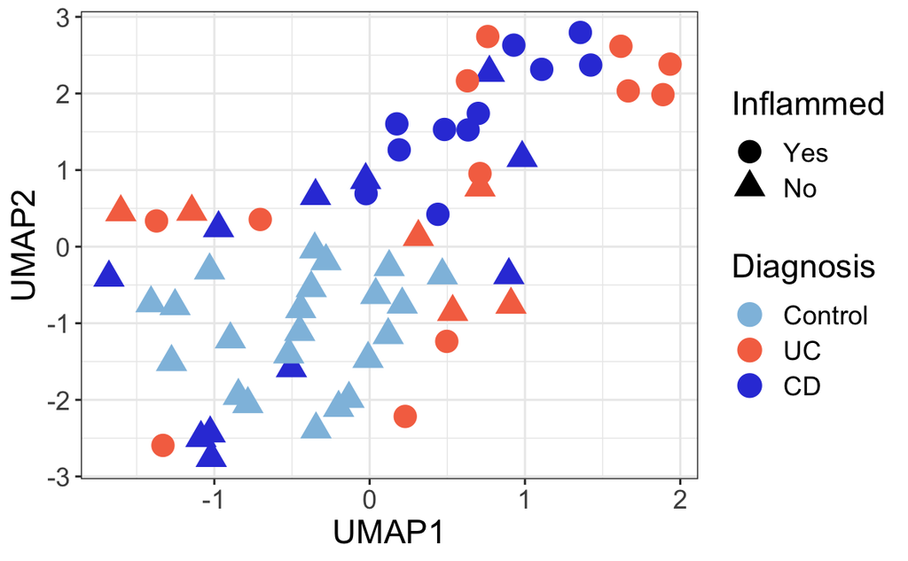

```r
ms1_umap <- umap(imputed_feat$data %>% as.matrix %>% t(), n_components=2, random_state=2248)
#ibd_meta <- ibd_meta[match(colnames(log_exp), ibd_meta$NewName),]
coords_umap<-data.frame(ms1_umap$layout, Diagnosis = ac_metadata$Diagnosis,
                   #samplename = colnames(log_exp_DC),
                   Sex = ac_metadata$Gender,
                   #Site = ac_metadata$Location,
                   Inflammed = ac_metadata$Inflammed, Date=ac_metadata$Date)
coords_umap$Diagnosis <- factor(coords_umap$Diagnosis, levels = c("Control", "UC", "CD"))
coords_umap$Inflammed <- factor(coords_umap$Inflammed, levels = c("Yes","No"))
labels <- pretty(coords_umap$Date, 5)
(umap_plot_diagnosis <- ggplot(coords_umap, aes(x = X1, y = X2)) +
        geom_point(size=5, aes(shape = Inflammed, color = Diagnosis)) +
        scale_color_manual(values=c("#8FBFE0", "#F57251",  "#3444DA"))+
        #scale_color_gradient(
  #  low="yellow", high="purple",
  #  breaks = as.integer(labels),
  #  labels = format(labels, "%m/%d/%y")
 # ) +
        scale_x_continuous(name="UMAP1") +
        scale_y_continuous(name="UMAP2") +
        theme_bw() +
        theme(legend.position = "right", text=element_text(size=16)))
```

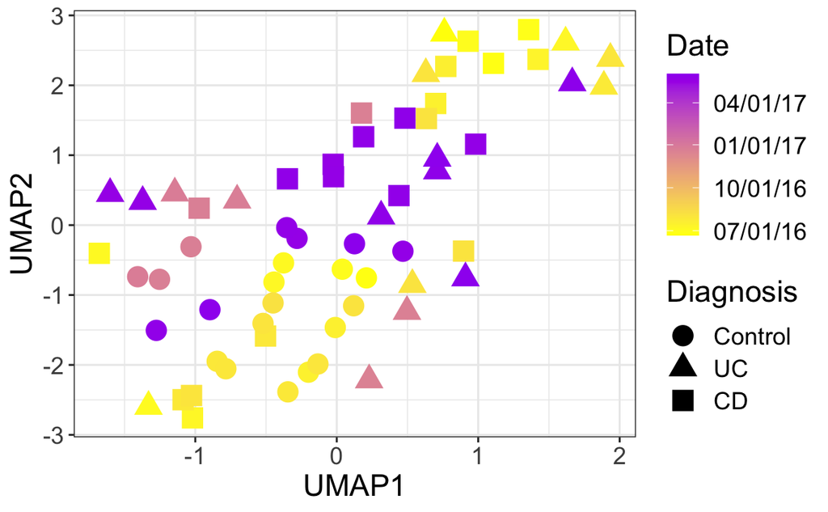

```r
(umap_plot_date <- ggplot(coords_umap, aes(x = X1, y = X2)) +
        geom_point(size=5, aes(shape = Diagnosis, color = Date)) +
        #scale_color_manual(values=c("#3444DA",  "#DF737A", "#8C5999", "#00916E", "#D7C0D0", "#FFBA49")) +
        scale_color_gradient(
    low="yellow", high="purple",
    breaks = as.integer(labels),
    labels = format(labels, "%m/%d/%y")
  ) +
        scale_x_continuous(name="UMAP1") +
        scale_y_continuous(name="UMAP2") +
        theme_bw() +
        theme(legend.position = "right", text=element_text(size=16)))
```

```r
#ggsave(filename = "../figs/umap-ac-diagnosis.pdf", umap_plot_diagnosis, width = 8, height = 6, units = "in")
#ggsave(filename = "../figs/umap-ac-date.pdf", umap_plot_date, width = 8, height = 6, units = "in")
```

## Log2 intensity transformation and PCA quality check

We then should log transform the intensity values and perform a PCA for a QC check.

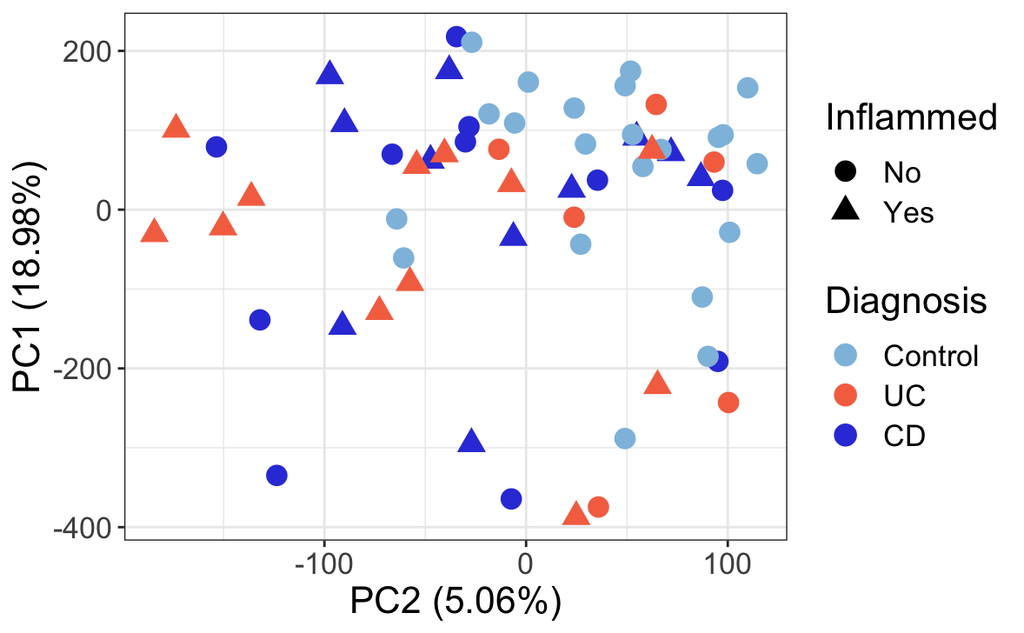

```r
## easy and quick PCA function for manual colour and shape
## easy and quick PCA function for manual colour and shape
quick_pca <- function(coords_df, x_PC, y_PC, PoV, shape, fill){
    yaxis <- y_PC
    xaxis <- x_PC
    yperc <- paste0("(", round(PoV[yaxis %>% as.numeric()] ,2), "%)")
    xperc <- paste0("(", round(PoV[xaxis %>% as.numeric()] ,2), "%)")
    yaxislabel <- paste0("PC", yaxis, " ", yperc)
    xaxislabel <- paste0("PC", xaxis, " ", xperc)
    pca_plot <- ggplot(coords_df, aes_string(x = paste0('PC', xaxis), y = paste0('PC', yaxis))) +
        geom_point(size=4, aes_string(shape = shape, color = fill)) +
        #scale_color_manual(values=c("#3444DA",  "#DF737A", "#8C5999", "#00916E", "#D7C0D0", "#FFBA49")) +
        scale_color_manual(values=c("#8FBFE0", "#F57251",  "#3444DA"))+
        scale_x_continuous(name=xaxislabel) +
        scale_y_continuous(name=yaxislabel) +
        theme_bw() +
        theme(legend.position = "right", text=element_text(size=16))
    return(pca_plot)
}

## easy and quick PCA funcDCon for manual colour and shape
quick_pca_date <- function(coords_df, x_PC, y_PC, PoV, shape, fill){
    yaxis <- y_PC
    xaxis <- x_PC
    yperc <- paste0("(", round(PoV[yaxis %>% as.numeric()] ,2), "%)")
    xperc <- paste0("(", round(PoV[xaxis %>% as.numeric()] ,2), "%)")
    yaxislabel <- paste0("PC", yaxis, " ", yperc)
    xaxislabel <- paste0("PC", xaxis, " ", xperc)
    pca_plot <- ggplot(coords_df, aes_string(x = paste0('PC', xaxis), y = paste0('PC', yaxis))) +
        geom_point(size=4, aes_string(shape = shape, color = fill)) +
        #scale_color_manual(values=c("#3444DA",  "#DF737A", "#8C5999", "#00916E", "#D7C0D0", "#FFBA49")) +
  scale_color_gradient(
    low="yellow", high="purple",
    breaks = as.integer(labels),
    labels = format(labels, "%m/%d/%y")
  ) +
      scale_x_continuous(name=xaxislabel) +
        scale_y_continuous(name=yaxislabel) +
        theme_bw() +
        theme(legend.position = "right", text=element_text(size=16))
    return(pca_plot)
}


log_exp <- data.frame(imputed_feat$data) %>%
    mutate_all(., funs(log2(1 + .)))
colnames(log_exp) = colnames(imputed_feat$data)
pca_all<- prcomp(log_exp %>% t(), center=T, scale=F)
sampleVals<-data.frame(pca_all$x)
exprVals<-data.frame(pca_all$rotation)
PoV <- (pca_all$sdev^2/sum(pca_all$sdev^2))*100

coords<-data.frame(sampleVals, Diagnosis = ac_metadata$Diagnosis,
                   samplename = rownames(sampleVals),
                   Sex = ac_metadata$Gender,
                   #Site =  ac_metadata$Location,
                   Inflammed =  ac_metadata$Inflammed, Date= ac_metadata$Date) #,
                   #Age = ibd_meta$Age)
coords$Diagnosis <- factor(coords$Diagnosis, levels = c("Control", "UC", "CD"))
numPCs_all <- 1:length(PoV)

for (i in 1:length(PoV)) {
    percent <- paste0("(", round(PoV[i],2), "%)")
    name <- paste0("PC", i, "per")
    assign(name, percent)
}
(pc12 <- quick_pca(coords_df = coords, x_PC = 2, y_PC = 1, PoV = PoV, shape = "Inflammed", fill = "Diagnosis"))
```

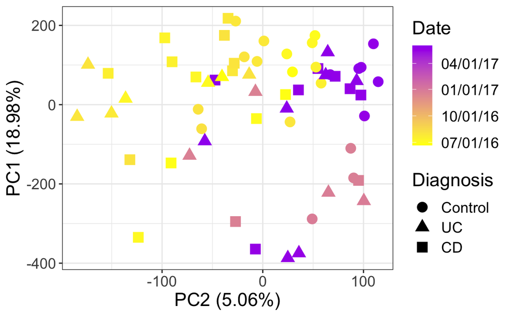

```r
(pc12_all <- quick_pca_date(coords_df = coords, x_PC = 2, y_PC = 1, PoV = PoV, shape = "Diagnosis", fill = "Date"))
```

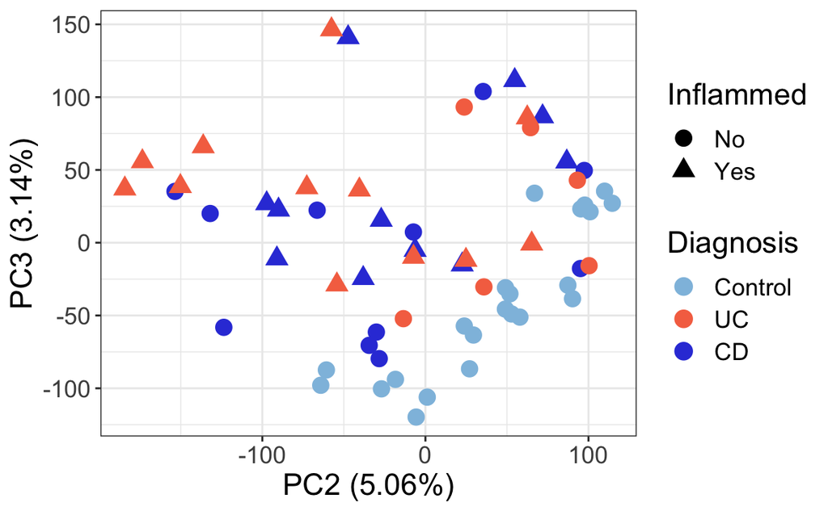

```r
(pc23_all <- quick_pca(coords_df = coords, x_PC = 2, y_PC = 3, PoV = PoV, shape = "Inflammed", fill = "Diagnosis"))
```

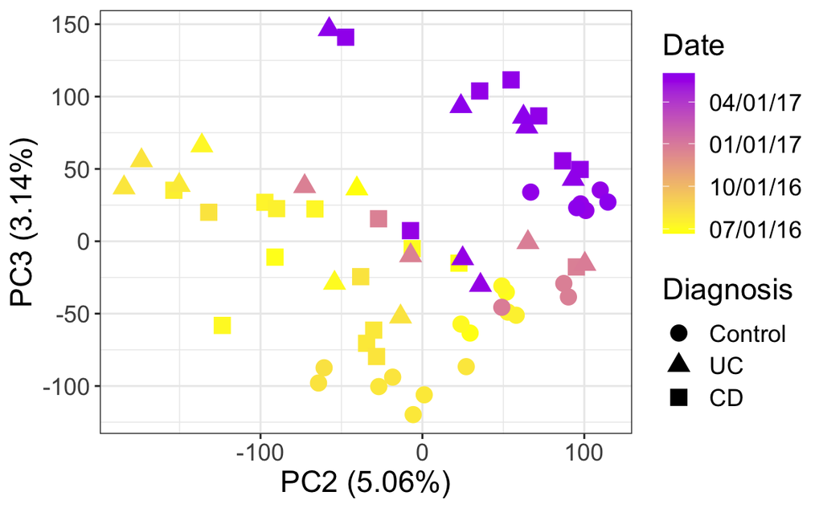

```r
(pc23_all <- quick_pca_date(coords_df = coords, x_PC = 2, y_PC = 3, PoV = PoV, shape = "Diagnosis", fill = "Date"))
```

## Calculating log2 fold change

We are using [precise-db’s](https://github.com/SBRG/precise-db) implementation of robust components in ICA matrix decomposition. This implementation required fold change values.

We need to write this log2 FC to a file because the ICA implementation is written in Python.

### All samples

```r
ctrl_all <- dplyr::select(log_exp, contains("Control"))
ctrl_all$median = apply(ctrl_all, 1, median, na.rm = T)
group_temp_all <- dplyr::select(log_exp, -contains("Control"))
ctrl_all<- matrix(ctrl_all$median, nrow=length(ctrl_all$median), ncol=ncol(group_temp_all), byrow=F)

fc_all <- ctrl_all - group_temp_all

all_samples_noctrl <- ac_metadata  %>% dplyr::filter(Diagnosis != "Control")# %>%
    #mutate(Name = paste0(., "_", Groups))

fc_all <- fc_all %>% dplyr::select(all_samples_noctrl$NewName)
#write.csv(fc_all, here::here("ibd","ac", "nc-ibd_ms1_fc-acOnly.csv"), quote=F, row.names = T)
```

## Cluster eigenfeature calculation and clustering visualization

```r
## I manually chose k=20... is this the best choice?
kmedoid_labels <- read.csv(here::here("ibd", "ac", "k-med_labels.csv"), header=F) %>% as.vector()

clusterinfopep <- kmedoid_labels %>% data.frame()

max_clust <- kmedoid_labels %>% unique() %>% max()
print(paste("Number of clusters:", max_clust))
```

```
[1] "Number of clusters: 25"
```

```r
fc_clusters <- list()

noctrlmeta <- ac_metadata %>% filter(Diagnosis != "Control")

## making sure our FC data is
fc_all <- fc_all %>% dplyr::select(noctrlmeta$NewName)
## creating a list that contains intensities of each peptide cluster
for (x in 0:max_clust){
    clustername <- paste("Cluster", x)
    y <- kmedoid_labels[which(kmedoid_labels$V1 == x),,drop=F] %>% rownames()
    fc_clusters[[clustername]] <- fc_all[y %>% as.numeric(),]
    fc_clusters[[clustername]]$feat_num <- y
}

### eigenfactors
### Singular value decomposition for genome-wide expression data processing and modeling
###  https://doi.org/10.1073/pnas.97.18.10101
## https://www.biostars.org/p/299167/
## eigengenes <- svd(X)$v


svd_clusters <- lapply(fc_clusters, function(x) svd(x %>% dplyr::select(-feat_num))$v)
# grabbing the first principal component
svd1_cluster <- lapply(svd_clusters,  "[", , 1)


clustereigenfactors_svd <- bind_cols(svd1_cluster) %>% data.frame()
```

Complete the correlation with groups and inflammation.

```r
## make a factored dataframe of the compounds

noctrlmeta <- noctrlmeta %>% mutate(diag_inflam = paste0(Diagnosis, "_", Inflammed))

datTraits <- data.frame(diag_inflam =  as.factor(noctrlmeta$diag_inflam))
rownames(datTraits) <- noctrlmeta$NewName
traits <- model.matrix(~ ., data=datTraits,
                       contrasts.arg = lapply(datTraits, contrasts, contrasts=FALSE))
traits <- traits[,-1] ##removing intercept
#moduleTraitCor_pca <- stats::cor(clustereigenfactors_pca, traits, method = "s")
moduleTraitCor_svd <- stats::cor(clustereigenfactors_svd, traits, method = "s")
#colnames(moduleTraitCor_pca) <- colnames(moduleTraitCor_pca) %>% substr(., 10, nchar(colnames(moduleTraitCor_pca)))
colnames(moduleTraitCor_svd) <- colnames(moduleTraitCor_svd) %>% substr(., 12, nchar(colnames(moduleTraitCor_svd)))
```

Now, let’s look at *SVD-derived* eigenfeatures (this is the more common way of calculating an eigenfeature).

```r
module_clust_svd <- hclust(as.dist(1-cor(t(moduleTraitCor_svd), method="pearson")), method="average")
drug_clust_svd <- hclust(as.dist(1-cor(moduleTraitCor_svd, method="pearson")), method="average")
drug_clust_boot_svd <- pvclust(moduleTraitCor_svd, method.hclust="average",
                           method.dist="correlation", nboot=1000,
                           iseed=2248)
```

```
Bootstrap (r = 0.5)... Done.
Bootstrap (r = 0.58)... Done.
Bootstrap (r = 0.69)... Done.
Bootstrap (r = 0.77)... Done.
Bootstrap (r = 0.88)... Done.
Bootstrap (r = 1.0)... Done.
Bootstrap (r = 1.08)... Done.
Bootstrap (r = 1.19)... Done.
Bootstrap (r = 1.27)... Done.
Bootstrap (r = 1.38)... Done.
```

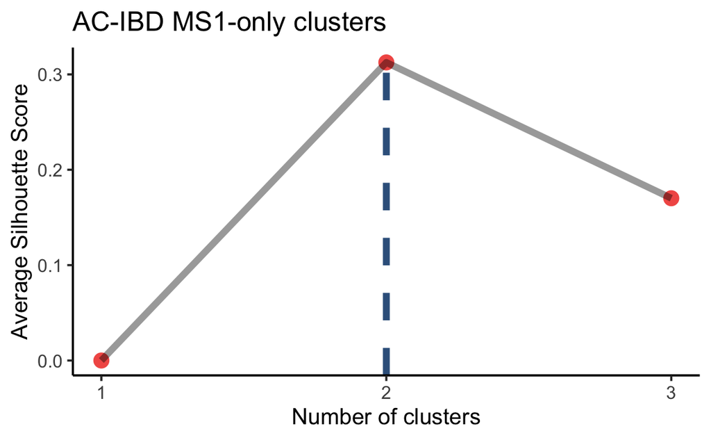

```r
quick_sil <- function(hclust_out, distance, max_k){
  silhouette_score <- function(i){
    k=cutree(hclust_out,i)
    ss <- silhouette(k, 1-cor(distance, method="pearson"))
    mean(ss[, 3])
    }
  clustnum <- 2:max_k
  avg_sil <- sapply(clustnum, silhouette_score)
  avg_sil <- data.frame(num = clustnum, sil_score = avg_sil)
  avg_sil <- rbind(c(1,0), avg_sil)
  return(avg_sil)
}
#
ms1_svd_sil <- quick_sil(hclust_out=drug_clust_svd, distance = 1-cor(moduleTraitCor_svd, method="pearson"), max_k = 3)
(ms1_sil <- ggplot(ms1_svd_sil, aes(x=num, y = sil_score)) +
  geom_point(size=4, colour="#F25C54", alpha=1) +
    geom_line(size=2, alpha=0.4) +
    geom_vline(xintercept=2, size = 2, linetype="dashed", color = "#38618C") +
    xlab("Number of clusters") +
    ylab("Average Silhouette Score") +
    scale_x_continuous(breaks = 1:30) +
    theme_classic(base_size=14) +
    ggtitle("AC-IBD MS1-only clusters")
)
```